# COVID-19 dynamic vaccination strategy simulations

```r
#library(covoid)
devtools::load_all()
library(ggplot2)
```

This vignette details how to program and simulate dynamic vaccine strategies. These are situations where at time 0 some (small) percentage of the population is vaccinated, and as time progresses this percentage is increased according to a user defined strategy. There may be infectious cases present in the population at time zero or imported as time progresses. There is an additional vignette detailing the “static” case where X% of the population are vaccinated at time 0 and no additional vaccinations are performed.

## to add

- example with vaccine rates different per group
- example with antivaxxers
- example with n arrivals per day with P(covid) (per age)

## Model Description

In order to simplify some aspects of programming it is a discrete time step model, $\Delta t = 1$ with each time step interpretable as 1 hour/day/week as required. The models are age structured. For background information on age structured compartmental models see `vignette(age-structured-mixing-background)` and for programming information see `vignette(age-structured-mixing)`.

## Vaccine effectiveness

Simulating an age structured compartmental model requires a contact matrix and age distribution. Some additional modeling for the dynamic vaccine model include:

- Imported cases
- Vaccination strategy
- Vaccine effectiveness

### Demographics

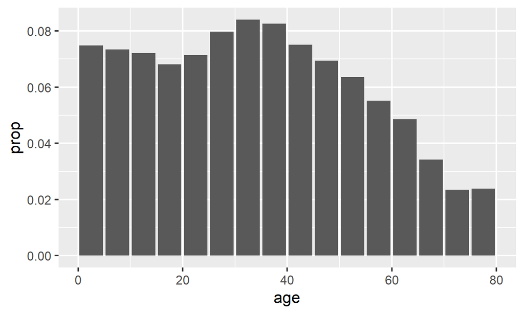

```r
cm_oz <- import_contact_matrix("Australia","general")
nJ <- ncol(cm_oz)
dist_oz <- import_age_distribution("Australia")
SSv <- dist_oz*5e6
plot(dist_oz)
```

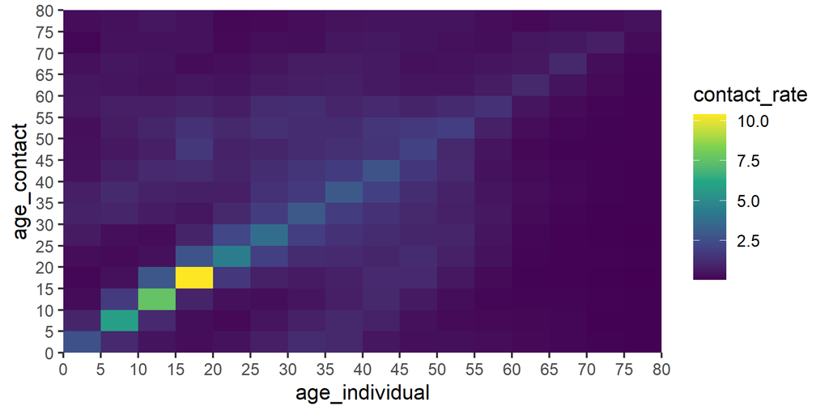

```r
plot(cm_oz)
```

### Vaccination strategies

#### Random vaccination

One possible strategy would be to randomly vaccinate members of the population until everyone has been vaccinated. We might assume that this will lead to a vaccination rate per age group that is proportional to their percentage of the population. The function `vaccination_allocation` can be used to achieve this.

```r
vaccination_allocation <- function(n,s,vac_params) {
    # n: number of available vaccines
    # s: number of people in group j
    # in vac_params:
    # p: probability of group j getting vaccinates

    with(vac_params,{
        # number vaccinated
        nvac0 <- pmin(p*n,s*ceiling(p))
        remaining_vac <- n - sum(nvac0)

        # allocate remaining vaccines
        while(remaining_vac > 1 & any((nvac0 != s)[as.logical(ceiling(p))])) {
            fully_allocated <- nvac0 == s
            p1 <- (p*!fully_allocated)/sum(p*!fully_allocated)
            nvac0 <- pmin(nvac0 + p1*remaining_vac,s*ceiling(p))
            remaining_vac <- n - sum(nvac0)
        }
        return(nvac0)
    })
}
```

The graph below shows the pattern if we randomly vaccinate 10,000 people per day for population similar to Sydney.

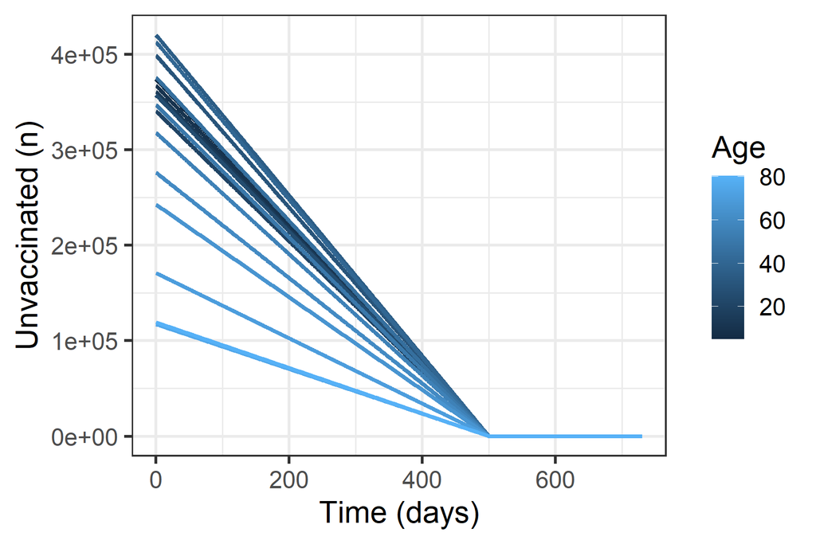

```r
# simulate vaccination
TT <- floor(365*2)
SSvt <- matrix(nrow = TT+1,ncol=length(SSv))
SSvt[1,] <- SSv
nvac_per_day <- 10000
for (t in 2:(TT+1)) {
    nvac_t <- vaccination_allocation(nvac_per_day,SSvt[(t-1),],list(p=dist_oz))
    SSvt[t,] <- SSvt[(t-1),] - nvac_t
}

# plot the resulting vaccination rate graph
SSvt <- data.frame(SSvt)
names(SSvt) <- seq(5,80,5)
SSvt$day <- 0:TT
SSvt <- tidyr::pivot_longer(SSvt,cols=-17,names_to="age_group",values_to="n")
SSvt$age_group <- as.numeric(SSvt$age_group)
ggplot(SSvt,aes(x=day,col=age_group,,group=factor(age_group),y=n)) +
    geom_line(size=1) +
    theme_bw(base_size = 16) +
    labs(x = "Time (days)", y= "Unvaccinated (n)") +
    scale_color_continuous(name="Age")
```

#### Random vaccination with no vaccination of those under 15

As the title says! We set the probability of being vaccinated to zero for three age groups.

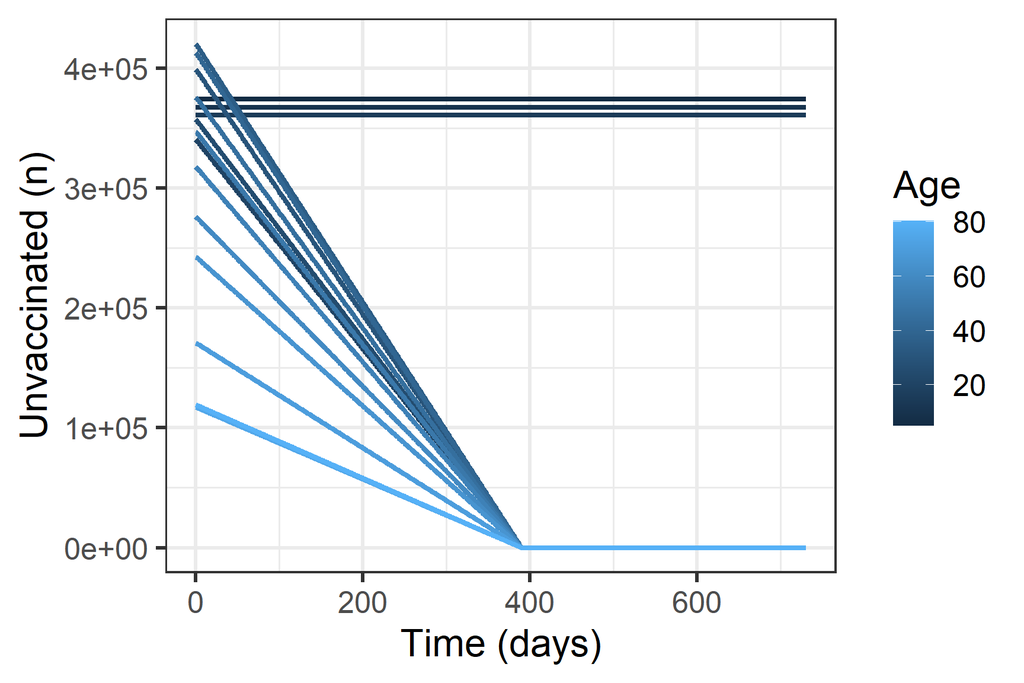

```r
# simulate vaccination
TT <- floor(365*2)
SSvt <- matrix(nrow = TT+1,ncol=length(SSv))
SSvt[1,] <- SSv
nvac_per_day <- 10000
prob_vaccine <- dist_oz
prob_vaccine[1:3] <- 0.0
prob_vaccine <- prob_vaccine/sum(prob_vaccine)
for (t in 2:(TT+1)) {
    nvac_t <- vaccination_allocation(nvac_per_day,SSvt[(t-1),],list(p=prob_vaccine))
    SSvt[t,] <- SSvt[(t-1),] - nvac_t
}

# plot the resulting vaccination rate graph
SSvt <- data.frame(SSvt)
names(SSvt) <- seq(5,80,5)
SSvt$day <- 0:TT
SSvt <- tidyr::pivot_longer(SSvt,cols=-17,names_to="age_group",values_to="n")
SSvt$age_group <- as.numeric(SSvt$age_group)
ggplot(SSvt,aes(x=day,col=age_group,,group=factor(age_group),y=n)) +
    geom_line(size=1) +
    theme_bw(base_size = 16) +
    labs(x = "Time (days)", y= "Unvaccinated (n)") +
    scale_color_continuous(name="Age")
```

#### Random vaccination with decreasing efficacy

The random vaccination graph above seems too linear. We might expect that the rate of vaccinations varies. For instance it might start off a little slow, then reach a peach before again slowing down as those too busy or hesitant to get the vaccine remain. For the more pessimistic case we may have something like the graph below describing how many of our allocated vaccines are actually used.

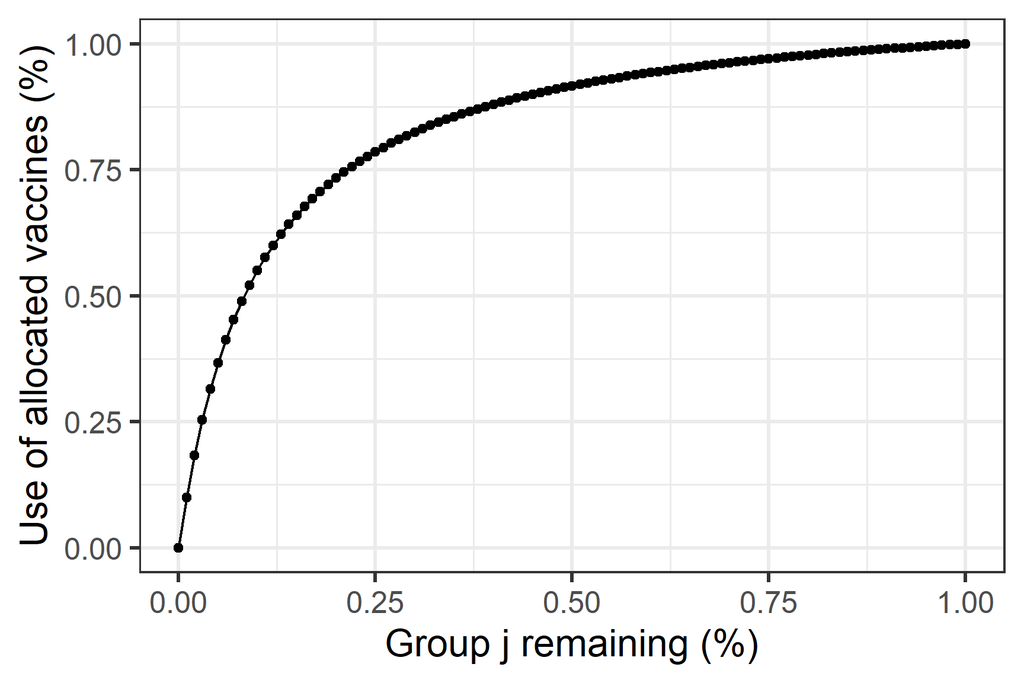

```r
mm <- function(p,half) {
    # Michaelis–Menten like dynamics
    # p: proportion vaccinated
    # half: point at which vaccination rate halfs
    (p/(p+half))*(1.0+half)
}

df <- data.frame(p = seq(0,1,0.01),vac_rate = mm(seq(0,1,0.01),0.1))
ggplot(df,aes(x=p,y=vac_rate)) +
    geom_line() +
    geom_point() +
    coord_cartesian(ylim=c(0,1)) +
    theme_bw(base_size = 16) +
    labs(x = "Group j remaining (%)",
         y="Use of allocated vaccines (%)")
```

How does this alter the linear curves above? First alter the allocation function.

```r
vaccination_allocation_mm <- function(n,s,vac_params) {
    # n: number of available vaccines
    # s: number of people in group j
    # in vac_params:
    # p: probability of group j getting vaccinates
    # s0: group size at time 0
    # half: percentage of population at which slow down begins

    with (vac_params, {
        # number vaccinated
        nvac0 <- pmin(p*n,s*ceiling(p))
        remaining_vac <- n - sum(nvac0)

        # allocate remaining vaccines
        while(remaining_vac > 1 & any((nvac0 != s)[as.logical(ceiling(p))])) {
            fully_allocated <- nvac0 == s
            p1 <- (p*!fully_allocated)/sum(p*!fully_allocated)
            nvac0 <- pmin(nvac0 + p1*remaining_vac,s*ceiling(p))
            remaining_vac <- n - sum(nvac0)
        }
        return(nvac0*mm(s/s0,half))
    })
}
```

As expected vaccinating everyone now takes a little longer.

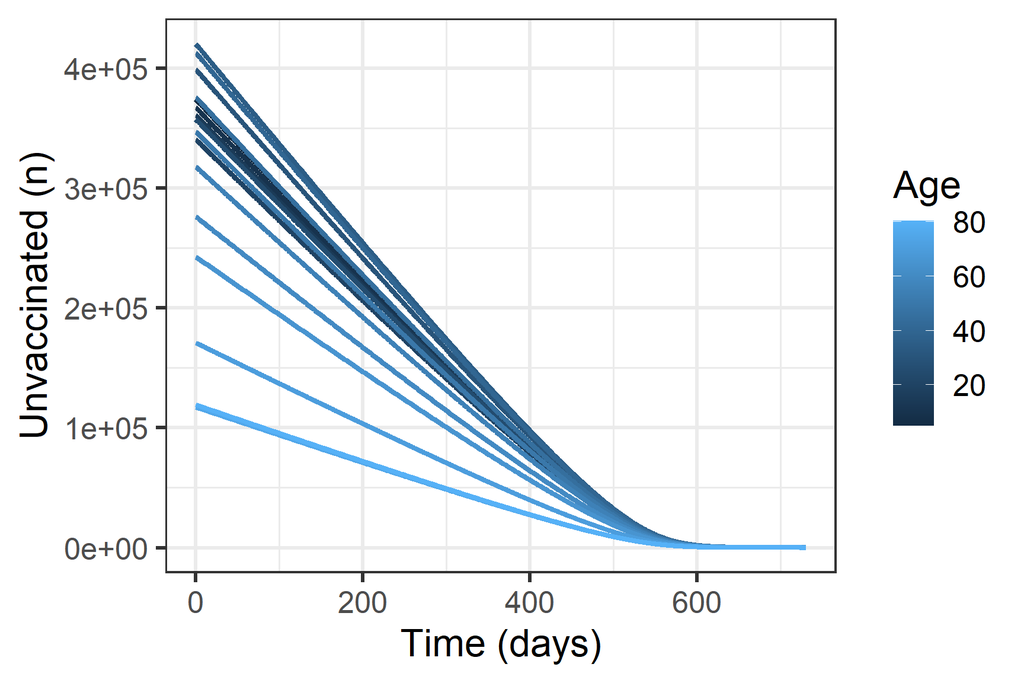

```r
# simulate vaccination
TT <- floor(365*2)
SSvt <- matrix(nrow = TT+1,ncol=length(SSv))
SSvt[1,] <- SSv
nvac_per_day <- 10000
half <- 0.05
for (t in 2:(TT+1)) {
    nvac_t <- vaccination_allocation_mm(nvac_per_day,
                                    SSvt[(t-1),],list(p=dist_oz,s0=SSv,half=half))
    SSvt[t,] <- SSvt[(t-1),] - nvac_t
}

# plot the resulting vaccination rate graph
SSvt <- data.frame(SSvt)
names(SSvt) <- seq(5,80,5)
SSvt$day <- 0:TT
SSvt <- tidyr::pivot_longer(SSvt,cols=-17,names_to="age_group",values_to="n")
SSvt$age_group <- as.numeric(SSvt$age_group)
ggplot(SSvt,aes(x=day,col=age_group,,group=factor(age_group),y=n)) +
    geom_line(size=1) +
    theme_bw(base_size = 16) +
    labs(x = "Time (days)", y= "Unvaccinated (n)") +
    scale_color_continuous(name="Age")
```

#### COVID-19 case fatalility rate prioritised vaccination

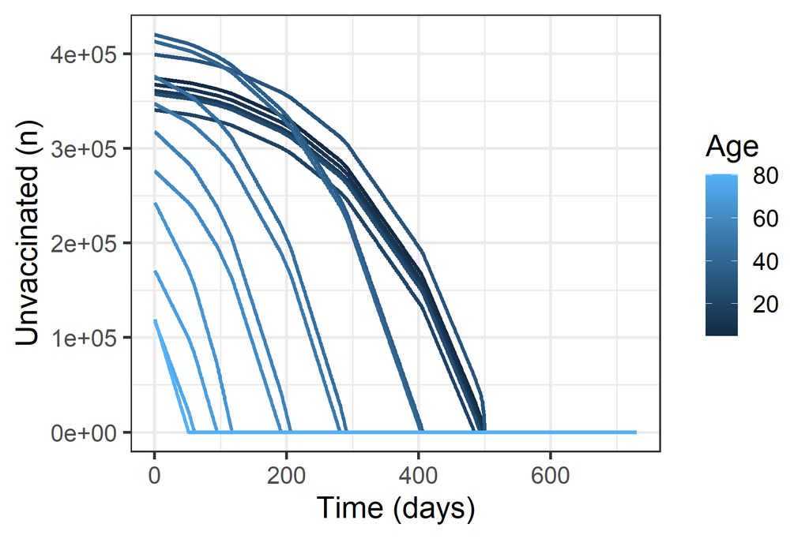

```r
dist_mortality <- c(0.01,0.01,0.01,0.01,
                    0.01,0.01,0.02,0.02,
                    0.04,0.04,0.07,0.07,
                    0.15,0.15,0.2,0.25)
prob_vaccine <- dist_mortality/sum(dist_mortality)

# simulate vaccinate
TT <- floor(365*2)
SSvt <- matrix(nrow = TT+1,ncol=length(SSv))
SSvt[1,] <- SSv
nvac_per_day <- 10000
half <- 0.05
for (t in 2:(TT+1)) {
    nvac_t <- vaccination_allocation(nvac_per_day,
                                    SSvt[(t-1),],list(p=prob_vaccine,s0=SSv,half=half))
    SSvt[t,] <- SSvt[(t-1),] - nvac_t
}

# plot the resulting vaccination rate graph
SSvt <- data.frame(SSvt)
names(SSvt) <- seq(5,80,5)
SSvt$day <- 0:TT
SSvt <- tidyr::pivot_longer(SSvt,cols=-17,names_to="age_group",values_to="n")
SSvt$age_group <- as.numeric(SSvt$age_group)
ggplot(SSvt,aes(x=day,col=age_group,,group=factor(age_group),y=n)) +
    geom_line(size=1) +
    theme_bw(base_size = 16) +
    labs(x = "Time (days)", y= "Unvaccinated (n)") +
    scale_color_continuous(name="Age")
```

#### Interaction with healthcare system prioritiesed vaccinations

An similar strategy to CFR strategy would be to vaccinate everyone who has an encounter with the healthcare system.

#### Workplace and school prioritised vaccination

An alternative strategy focused on limiting spread could be the vaccination of people while at work, school or university. Let’s focus on while at work, using the Australian workplace age specific contact matrix to construct allocation probabilities.

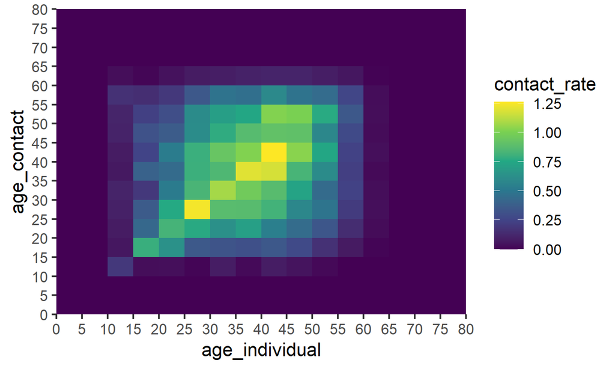

```r
plot(work_contact <- import_contact_matrix("Australia","work"))
```

I add 0.5 to the contact rates below as the 0 or near zero results for the young may results in numerical instability.

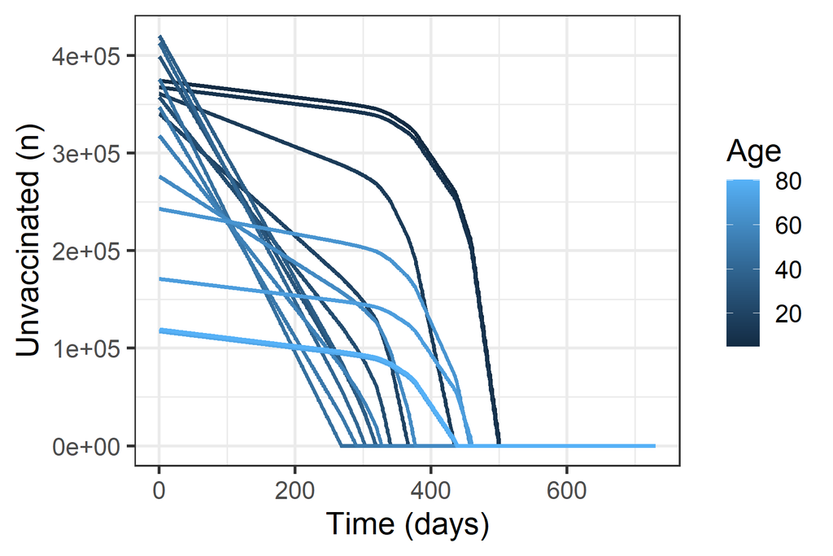

```r
total_work_contact <- colSums(work_contact)
prob_vaccine <- (total_work_contact + 0.5)/sum(total_work_contact +  0.5)

# simulate random vaccinate
TT <- floor(365*2)
SSvt <- matrix(nrow = TT+1,ncol=length(SSv))
SSvt[1,] <- SSv
nvac_per_day <- 10000
half <- 0.05
for (t in 2:(TT+1)) {
    nvac_t <- vaccination_allocation(nvac_per_day,
                                    SSvt[(t-1),],list(p=prob_vaccine,s0=SSv,half=half))
    SSvt[t,] <- SSvt[(t-1),] - nvac_t
}

# plot the resulting vaccination rate graph
SSvt <- data.frame(SSvt)
names(SSvt) <- seq(5,80,5)
SSvt$day <- 0:TT
SSvt <- tidyr::pivot_longer(SSvt,cols=-17,names_to="age_group",values_to="n")
SSvt$age_group <- as.numeric(SSvt$age_group)
ggplot(SSvt,aes(x=day,col=age_group,,group=factor(age_group),y=n)) +
    geom_line(size=1) +
    theme_bw(base_size = 16) +
    labs(x = "Time (days)", y= "Unvaccinated (n)") +
    scale_color_continuous(name="Age")
```

### Vaccine effectiveness

[interactive chart not shown]

*Figure 1:* Vaccination effectiveness

[interactive chart not shown]

*Figure 2:* Vaccination effectiveness

## Example simulation I - random vaccination

We’ll use the following setup:

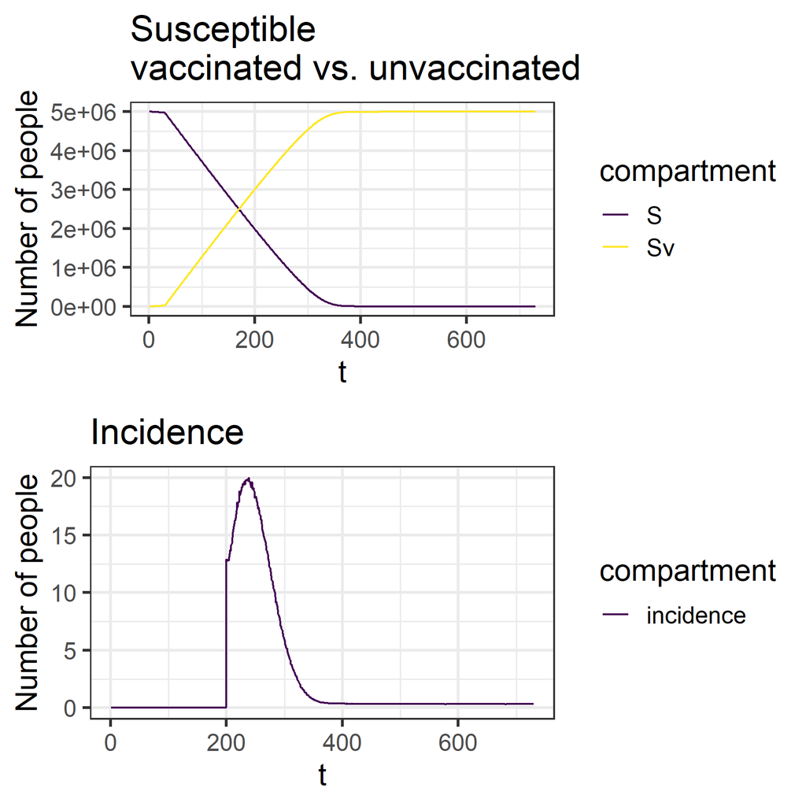

```r
## initial states
baseline <- 0.0
vaceff1 <- 0.99
vaceff2 <- 0.90
S <- SSv*(1-baseline)
Sv <- SSv*baseline
E <- rep(0,nJ)
Ev <- rep(0,nJ)
I <- Iv <- rep(0,nJ)
R <- Rv <- rep(0,nJ)
state0 <- seir_cv_state0(S = S,E = E,I = I,R = R,Sv = Sv,Ev = Ev,Iv = Iv,Rv = Rv)

## parameters
# imported case
n_imp_cases <- function(t,pvac) {
    0*(pvac <= 0.6) + (pvac > 0.6)*rpois(n = 1,lambda = 200)*0.05
}
# number of available vaccines
nvac <- function(t) {
    # number of available vaccinations (total)
    1000*(t < 30) + 20000*(t >= 30)
}
# vaccine allocation function
random_vac_alloc <- function(n,s) {
    vaccination_allocation_mm(n,s,list(p=dist_oz,s0=S,half=0.05))
}
param1 <- seir_cv_param(R0 = 2.5,
                        sigma=0.1,
                        gamma = 0.1,
                        cm=cm_oz,
                        dist=dist_oz,
                        vaceff1=vaceff1,
                        vaceff2=vaceff2,
                        nvac=nvac,
                        vac_alloc=random_vac_alloc,
                        n_imp=n_imp_cases)

## simulation
res1 <- simulate_seir_cv(t = 365*2,state_t0 = state0,param = param1)

## plot the results
p1 <- plot(res1,y = c("Sv","S")) +
    theme_bw(base_size = 16) +
    labs(title="Susceptible\nvaccinated vs. unvaccinated")
p2 <- plot(res1,y="incidence") +
    theme_bw(base_size = 16) +
    labs(title="Incidence")
gridExtra::grid.arrange(p1,p2,ncol=1)
```

## Example simulation II - random vaccination with vaccine hesitancy

Consider the case where a certain section of the population will refuse to be vaccinated regardless of the consequences (e.g. no international travel). We can model this by increasing the heterogeneity of the population to account for the presence of a certain percentage of vaccine refusers in each age group.

We’ll use the same setup as above, but now assume that 10% of every age group will never get vaccinated.

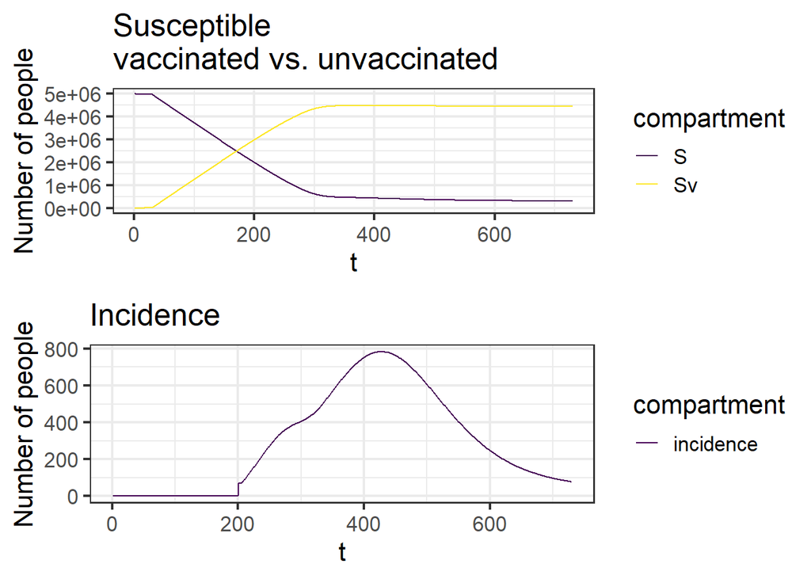

```r
## initial states
baseline <- 0.0
vaceff1 <- 0.99
vaceff2 <- 0.90
S <- rep(SSv*(1-baseline),each=2)*c(0.9,0.1)
Sv <- rep(SSv*baseline,each=2)*c(0.9,0.1)
E <- rep(0,nJ*2)
Ev <- rep(0,nJ*2)
I <- Iv <- rep(0,nJ*2)
R <- Rv <- rep(0,nJ*2)
state0 <- seir_cv_state0(S = S,E = E,I = I,R = R,Sv = Sv,Ev = Ev,Iv = Iv,Rv = Rv)

## parameters
# imported case
n_imp_cases <- function(t,pvac) {
    0*(pvac <= 0.6) + (pvac > 0.6)*rpois(n = 1,lambda = 200)*0.05
}
# number of available vaccines
nvac <- function(t) {
    # number of available vaccinations (total)
    1000*(t < 30) + 20000*(t >= 30)
}
# vaccine allocation function
dist_oz2 <- rep(dist_oz,each=2)/2
prob_vaccine <- rep(dist_oz,each=2)
prob_vaccine[seq(2,length(dist_oz2),by=2)] <- 0.0
random_vac_alloc <- function(n,s) {
    vaccination_allocation_mm(n,s,list(p=prob_vaccine,s0=S,half=0.05))
}
# contact matrix
cm_oz2 = matrix(ncol=ncol(cm_oz)*2,nrow=nrow(cm_oz)*2)
for (i in 1:(ncol(cm_oz)*2)) {
    cm_oz2[i,] <- rep(cm_oz[ceiling(i/2),],each=2)
}
param1 <- seir_cv_param(R0 = 2.5,
                        sigma=0.1,
                        gamma = 0.1,
                        cm=cm_oz2,
                        dist=dist_oz2,
                        vaceff1=vaceff1,
                        vaceff2=vaceff2,
                        nvac=nvac,
                        vac_alloc=random_vac_alloc,
                        n_imp=n_imp_cases)

## simulation
res1 <- simulate_seir_cv(t = 365*2,state_t0 = state0,param = param1)

## plot the results
p1 <- plot(res1,y = c("Sv","S")) +
    theme_bw(base_size = 16) +
    labs(title="Susceptible\nvaccinated vs. unvaccinated")
p2 <- plot(res1,y="incidence") +
    theme_bw(base_size = 16) +
    labs(title="Incidence")
gridExtra::grid.arrange(p1,p2,ncol=1)
```